# FinalEx

Oh

2021 3 8

FINAL EX

```r
library(foreign) # SPSS 파일 불러오기
library(dplyr)   # 전처리
library(doBy)    # 전처리
```

```r
library(ggplot2) # 시각화
library(readxl)  # 엑셀
rm(list=ls(all.names = TRUE))
raw_welfare <- read.spss(file='inData/Koweps/Koweps_hpc10_2015_beta1.sav', to.data.frame = T)
```

1. ‘한국복지패널데이터’(SPSS, koweps_hpc10_2015_beta5.sav)를 로드한 후 필요한 데이터 변수만을 select하여 변 수명을 변경하시오. 단 필요한 필드로 성별은 gender, 태어난 연도는 birth, 혼인상태는 marriage, 종교는 religion, 월평균임금은 income, 직업코드는 code_job, 지역코드는 code_region로 필드명을 변경한다.

```r
welfare <- raw_welfare[,c('h10_g3', 'h10_g4', 'h10_g10', 'h10_g11', 'p1002_8aq1', 'h10_eco9', 'h10_reg7')]
names(welfare) <- c('gender', 'birth', 'marriage', 'religion', 'income', 'code_job', 'code_region')
head(welfare)
```

```
##   gender birth marriage religion income code_job code_region
## 1      2  1936        2        2     NA       NA           1
## 2      2  1945        2        2     NA       NA           1
## 3      1  1948        2        2    120      942           1
## 4      1  1942        3        1    200      762           1
## 5      2  1923        2        1     NA       NA           1
## 6      1  1962        1        1     NA      530           1
```

2. 1번 문제의 결과인 data.frame변수를 이용하여 성별에 따른 월급 차이가 있는지를 분석하시오.

```r
table(is.na(welfare$gender))
```

```
##
## FALSE
## 16664
```

```r
welfare$gender <- ifelse(welfare$gender!=1&welfare$gender!=2, NA, welfare$gender)
welfare$gender <- ifelse(welfare$gender==1, 'male', 'female')
welfare$gender <- as.factor(welfare$gender)

#(1) 도표
welfare %>%
  group_by(gender) %>%
  summarise(ratio=n()/nrow(welfare)*100)
```

```
## # A tibble: 2 x 2
##   gender ratio
## * <fct>  <dbl>
## 1 female  54.5
## 2 male    45.5
```

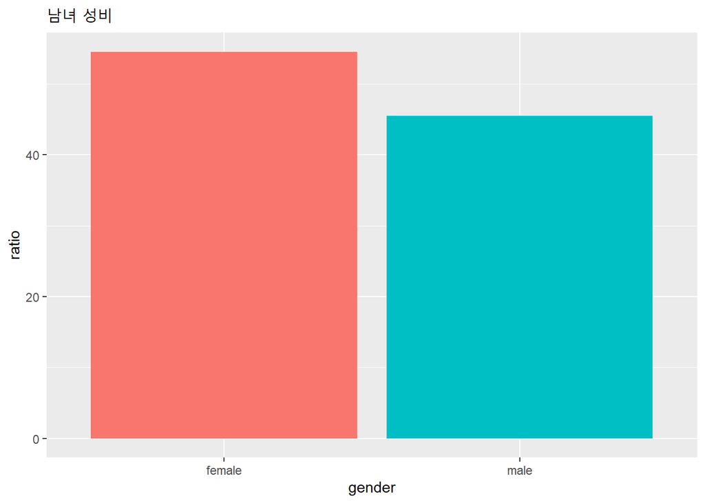

```r
#(2) 그래프
welfare %>%
  group_by(gender) %>%
  summarise(ratio = n()/nrow(welfare)*100) %>%
  ggplot(aes(x=gender, y=ratio)) +
  geom_col(aes(fill=gender)) +
  labs(title = "남녀 성비") +
  theme(legend.position = "none")
```

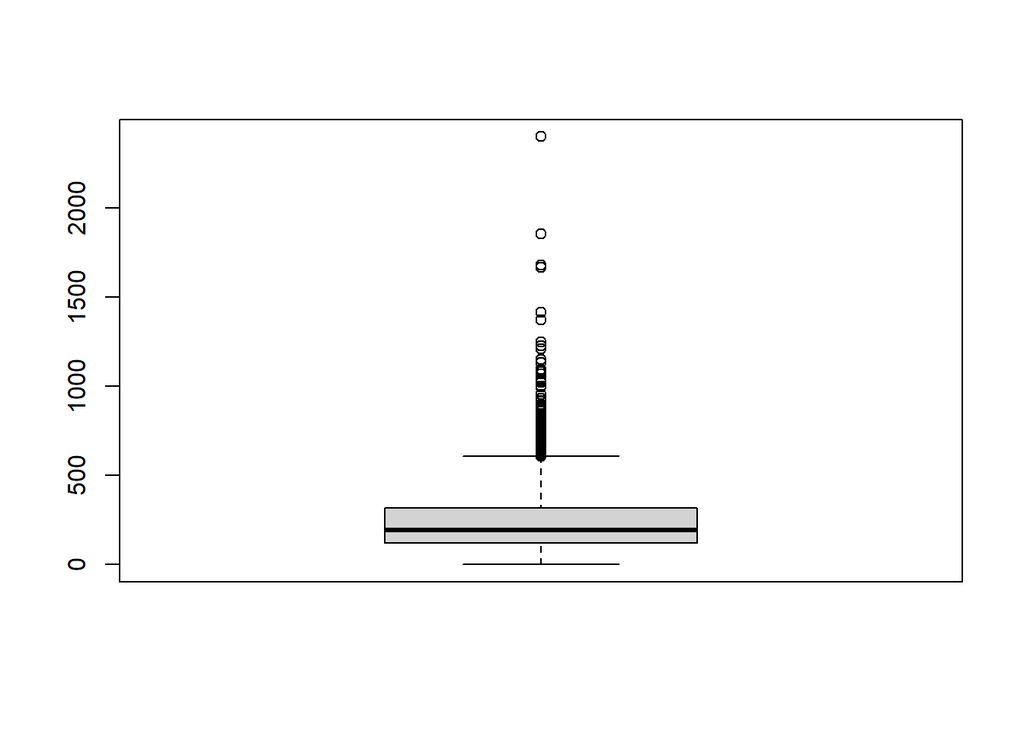

```r
inc <- boxplot(welfare$income)$stats
```

```r
welfare$income <- ifelse(welfare$income>inc[5]|welfare$income<inc[1], NA, welfare$income)
summary(welfare$income)
```

```
##    Min. 1st Qu.  Median    Mean 3rd Qu.    Max.    NA's
##     0.0   120.0   185.0   215.4   296.9   608.0   12238
```

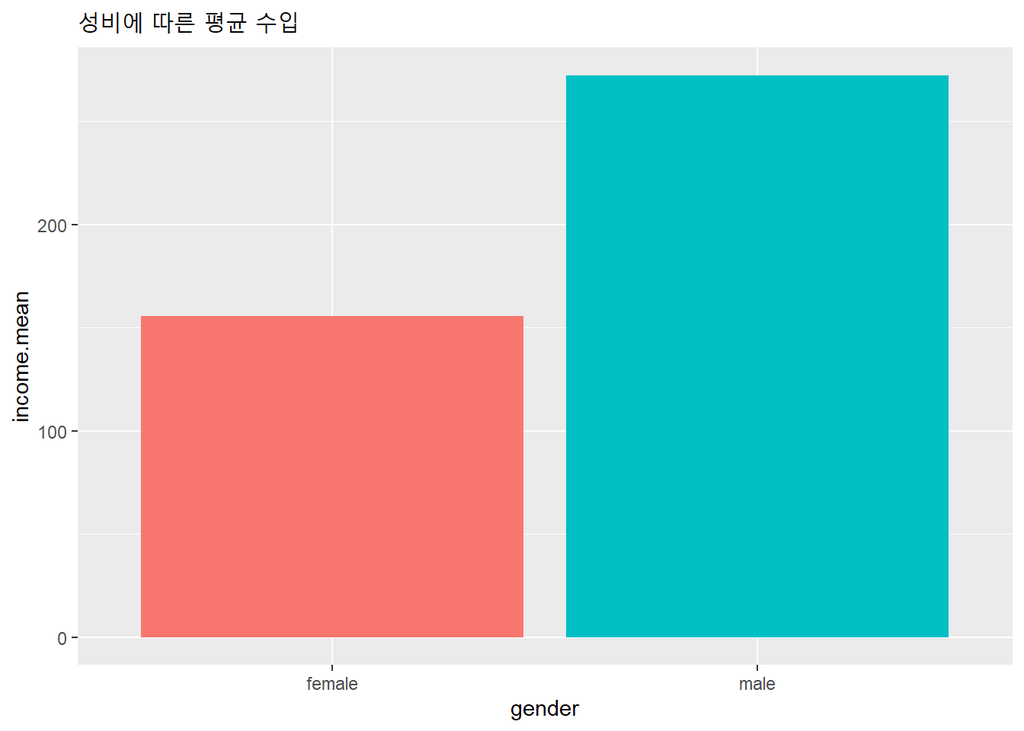

```r
welfare %>%
  filter(!is.na(income)) %>%
  group_by(gender) %>%
  summarise(income.mean = mean(income),
            income.sd = sd(income)) %>%
  ggplot(aes(x=gender, y=income.mean)) +
  geom_bar(aes(fill=gender),stat = 'identity') +
  labs(title="성비에 따른 평균 수입")+
  theme(legend.position = "none")
```

```r
#(3) 통계적인 분석
temp <- welfare %>%  filter(!is.na(income))
View(temp)
var.test(income~gender, data=temp) # 등분산성 테스트
```

```
##
##  F test to compare two variances
##
## data:  income by gender
## F = 0.57321, num df = 2159, denom df = 2265, p-value < 2.2e-16
## alternative hypothesis: true ratio of variances is not equal to 1
## 95 percent confidence interval:
##  0.5273702 0.6230869
## sample estimates:
## ratio of variances
##            0.57321
```

```r
t.test(income~gender, data=temp, var.equal=F)
```

```
##
##  Welch Two Sample t-test
##
## data:  income by gender
## t = -32.56, df = 4210.7, p-value < 2.2e-16
## alternative hypothesis: true difference in means is not equal to 0
## 95 percent confidence interval:
##  -123.8360 -109.7699
## sample estimates:
## mean in group female   mean in group male
##             155.6084             272.4114
```